## What am I looking for?

I would like to know the relationship between droupout rate(county) and other social indicators. For example, how does school districts’ total budget, median household income and unemployment rate affect the droupout rate? Are they positive correlation? Or are there significant difference between rural and urban areas? After all, I would like to present my findings in a map and provide some general suggestions for WA government.

Here are the links that my data comes from:

1.Shape File: https://data.wa.gov/Demographics/WAOFM-GIS-County-Boundary/sep2-mdr8/data

2.Rural and urban areas: https://www.doh.wa.gov/Portals/1/Documents/1500/RUCAGuide.pdf

3.Census Data: State of Washington Open Data Platform and http://data.spokesman.com/census/2010/washington/counties/

4.School Districts and Public Schools’ data: National Center for Education Statistics https://www.ofm.wa.gov/washington-data-research/population-demographics/population-estimates/small-area-estimates-program

5.Schools’ budgets: https://nces.ed.gov/edfin/search/peergroupdata.asp?dataid=1&subdataid=1&mt=0&jobid={CDB9F6CF-266C-41A9-87ED-E0867B2EA370}

6.Household Incomes: https://www.ofm.wa.gov/sites/default/files/public/legacy/economy/hhinc/medinc.pdf

7.Droupout rates: https://dev.socrata.com/foundry/data.wa.gov/6g87-pu72

## Part1. Reading the data

```r
dropout<-read.csv("https://github.com/liuuw/PROJECT/raw/master/Dataset.csv")

dim(dropout)
```

```
## [1] 39 17
```

```r
names(dropout)
```

```
##  [1] "County"
##  [2] "Dropout_Rate"
##  [3] "Median_household_income_2012"
##  [4] "unemployment_rate"
##  [5] "single_female_with_children"
##  [6] "Rank_by_Percent_by_Column_B"
##  [7] "single_male_with_children"
##  [8] "American_indian_and_Native_Alaskan"
##  [9] "Black_percentage"
## [10] "White_percentage"
## [11] "TotalRevenuePerStudent"
## [12] "TotalFederalRevenuePerStudent"
## [13] "TotalLocalRevenuePerStudent"
## [14] "TotalStateRevenuePerStudent"
## [15] "Student_number"
## [16] "Number_of_public_schools"
## [17] "Region"
```

I choose some of relevent variables in the dataset that I think might have connection with the dependent varibable(dropout rates) to do the analysis.

Since there’s no missing value in WA counties’ census records or schools’ data, basic excel function like ‘if’,‘countif’,‘sum’ can clean the data well.

We can see that there are 39 counties in WA. I pick up 14 possible independent variables in total for each county and am wandering which might relate to the droupout rate best. After try and error, this analysis will focus more on ‘total revenue per student,’‘median household income,’ and ‘unemployment rate.’

There are also 39 counties in the attribute table of the WA shape file, which is really handy for us to merge the data and show it on the map.

For now, let’s look at the univariate exploration first.

```r
str(dropout)
```

```
## 'data.frame':    39 obs. of  17 variables:
##  $ County                            : Factor w/ 39 levels "Adams","Asotin",..: 1 2 3 4 5 6 7 8 9 10 ...
##  $ Dropout_Rate                      : num  19.6 23.6 14.6 21.6 51 ...
##  $ Median_household_income_2012      : int  42354 41703 62739 47265 41887 56054 39461 42752 48050 37548 ...
##  $ unemployment_rate                 : num  10.3 8.5 9.8 9.7 11.5 10 9 11.4 10.9 18.4 ...
##  $ single_female_with_children       : num  0.081 0.075 0.071 0.06 0.052 0.067 0.054 0.072 0.067 0.05 ...
##  $ Rank_by_Percent_by_Column_B       : int  16 9 27 14 2 25 23 19 31 36 ...
##  $ single_male_with_children         : num  0.041 0.023 0.03 0.028 0.024 0.028 0.022 0.033 0.031 0.038 ...
##  $ American_indian_and_Native_Alaskan: num  0.019 0.014 0.009 0.01 0.051 0.009 0.014 0.015 0.011 0.167 ...
##  $ Black_percentage                  : num  0.006 0.004 0.013 0.003 0.008 0.02 0.003 0.006 0.003 0.003 ...
##  $ White_percentage                  : num  0.625 0.943 0.824 0.793 0.87 0.854 0.93 0.889 0.796 0.763 ...
##  $ TotalRevenuePerStudent            : int  116003 21747 69509 83872 61014 97295 32795 65721 156019 85383 ...
##  $ TotalFederalRevenuePerStudent     : int  5810 1674 6894 6377 8682 4566 2400 4466 15122 25431 ...
##  $ TotalLocalRevenuePerStudent       : int  18386 5008 15072 18281 10968 30945 3676 17060 24598 4907 ...
##  $ TotalStateRevenuePerStudent       : int  91807 15065 47543 59209 41366 61787 26719 44197 116301 55045 ...
##  $ Student_number                    : int  4703 3296 35396 13329 10462 79279 472 16702 7249 853 ...
##  $ Number_of_public_schools          : int  15 11 60 38 29 133 4 44 21 12 ...
##  $ Region                            : Factor w/ 2 levels "Rural","Urban": 1 1 2 1 1 2 1 1 1 1 ...
```

## Univariate exploration:

Turn our attention to counties whose been classified as Rural/Urban. This is the distribution of its values nad its relative frequencies.

```r
is.data.frame(dropout)
```

```
## [1] TRUE
```

```r
length(dropout)
```

```
## [1] 17
```

```r
table(dropout$Region)
```

```
##
## Rural Urban
##    31     8
```

```r
prop.table(table(dropout$Region))
```

```
##
##     Rural     Urban
## 0.7948718 0.2051282
```

Then we can run Chi-square test to see if the difference is significant and how’s the measure of centrality for the Region (dichotomous values):

```r
library(tidyverse)
prop.table(table(dropout$Region))%>%chisq.test() # In order to see the value of X-squared
```

```
##
##  Chi-squared test for given probabilities
##
## data:  .
## X-squared = 0.3478, df = 1, p-value = 0.5554
```

```r
distribution= table(dropout$Region) # To see whether Rural or Urban area are the counities in
modeCount=max(distribution)
mode=distribution[distribution==modeCount]
names(mode)
```

```
## [1] "Rural"
```

## Part.II Take a look at the data

Let’s see the school districts’ revenue difference among these 39 counties and sort by their budget. (ggplot)

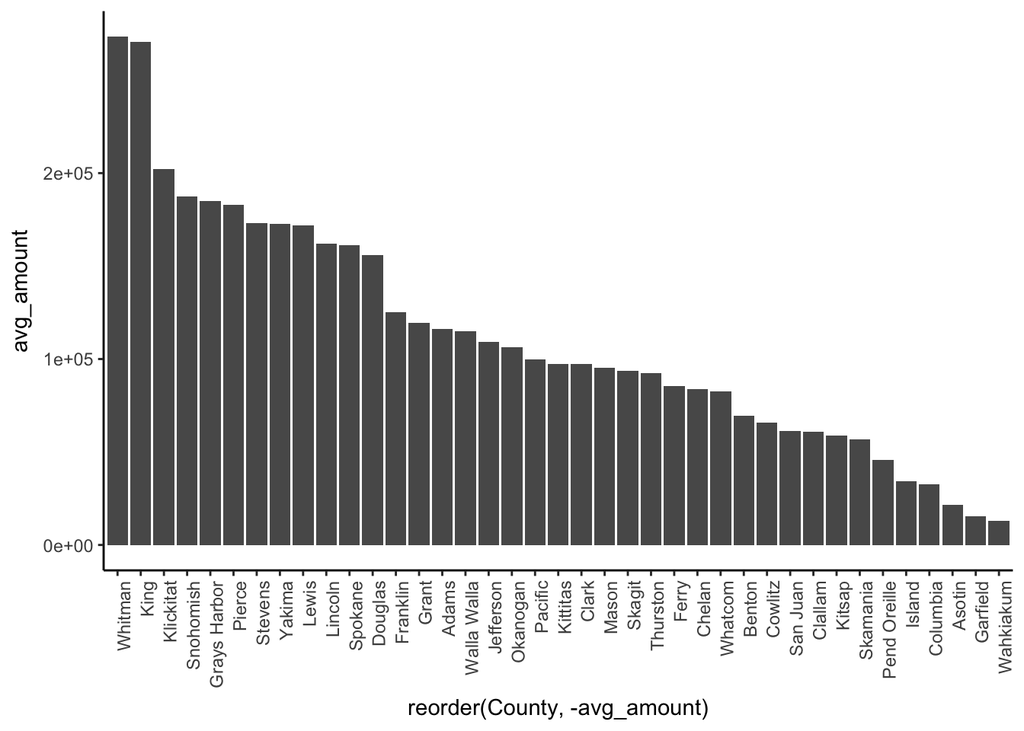

```r
library(ggthemes)
library(tidyverse)
library(ggplot2)

dropout %>%
  group_by(County) %>%
  summarise(avg_amount = mean(TotalRevenuePerStudent, na.rm = TRUE)) %>%
  ggplot(aes(reorder(County, -avg_amount), avg_amount)) +
  geom_bar(stat = 'identity') +
  scale_y_continuous() + theme_classic() +
  theme(axis.text.x = element_text(angle = 90, hjust = 1))
```

Let’s consider for this section the variable that tells us the highest total dropout rate and revenue according to each county.

```r
library(DescTools)
max(dropout$TotalRevenuePerStudent)
```

```
## [1] 273450
```

```r
min(dropout$TotalRevenuePerStudent)
```

```
## [1] 13172
```

```r
Median(dropout$TotalRevenuePerStudent)
```

```
## [1] 97463
```

```r
max(dropout$Dropout_Rate)
```

```
## [1] 53.19
```

```r
min(dropout$Dropout_Rate)
```

```
## [1] 3.57
```

```r
Median(dropout$Dropout_Rate)
```

```
## [1] 17.21
```

## Skewness and Kurtosis

We don’t need to do skewness and kutosis for this dataset, this part can be seemed as a practice.

```r
library(moments)
skewness(dropout[,c(2:16)],na.rm = T)
```

```
##                       Dropout_Rate       Median_household_income_2012
##                          1.6081532                          0.5518195
##                  unemployment_rate        single_female_with_children
##                          0.9729772                          0.3305370
##        Rank_by_Percent_by_Column_B          single_male_with_children
##                          0.0000000                          0.2372242
## American_indian_and_Native_Alaskan                   Black_percentage
##                          3.2900174                          2.5687051
##                   White_percentage             TotalRevenuePerStudent
##                         -1.0360756                          0.6629558
##      TotalFederalRevenuePerStudent        TotalLocalRevenuePerStudent
##                          0.9060911                          1.6649747
##        TotalStateRevenuePerStudent                     Student_number
##                          0.6284383                          3.3972968
##           Number_of_public_schools
##                          3.2855989
```

```r
library(moments)
kurtosis(dropout[,c(2:16)],na.rm = T)
```

```
##                       Dropout_Rate       Median_household_income_2012
##                           5.889418                           2.578426
##                  unemployment_rate        single_female_with_children
##                           4.498221                           2.793542
##        Rank_by_Percent_by_Column_B          single_male_with_children
##                           1.798421                           3.012229
## American_indian_and_Native_Alaskan                   Black_percentage
##                          14.436398                           9.863290
##                   White_percentage             TotalRevenuePerStudent
##                           3.398026                           3.052301
##      TotalFederalRevenuePerStudent        TotalLocalRevenuePerStudent
##                           2.933992                           6.632990
##        TotalStateRevenuePerStudent                     Student_number
##                           2.938721                          15.725174
##           Number_of_public_schools
##                          14.810873
```

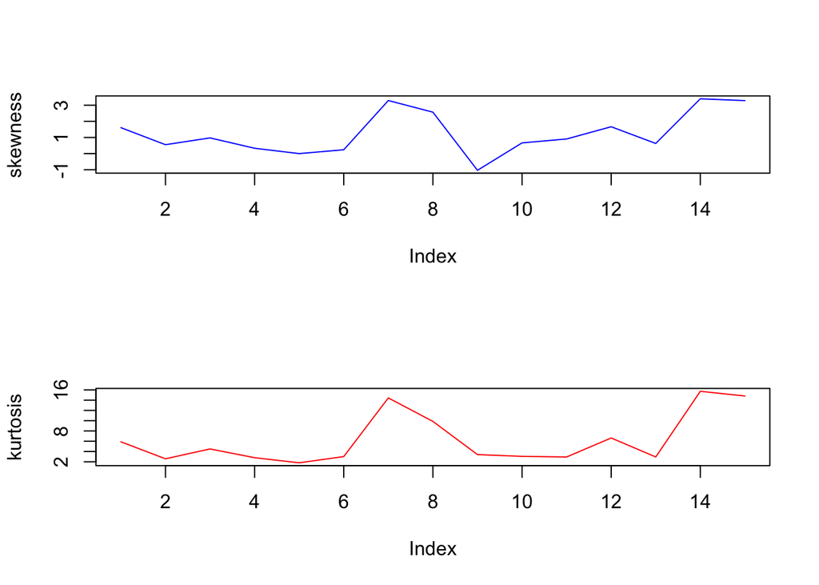

```r
# getting the 'years'
county=names(kurtosis(dropout[,c(2:16)],na.rm = T))


library(stringr)
library(moments)
county =str_extract(county, "\\d+")

# now we continue:
kt=kurtosis(dropout[,c(2:16)],na.rm = T)
sk=skewness(dropout[,c(2:16)],na.rm = T)
par(mfrow=c(2,1))
plot(sk,type = 'l',col='blue',ylab='skewness')
plot(kt,type = 'l',col='red',ylab='kurtosis')
```

## Histogram

From the previous part(max, min, median), we can see that the differences among counties are big, so we might want to understand their distributions a bit deeper.

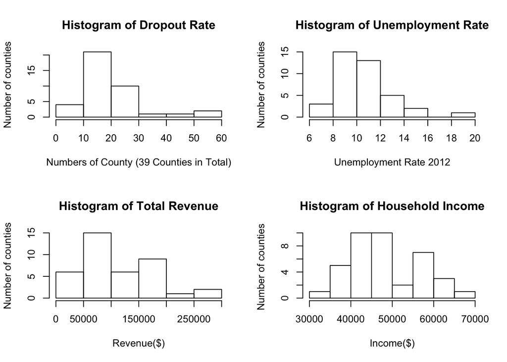

```r
par(mfrow = c(2,2))
hist(x=dropout$Dropout_Rate,
     main="Histogram of Dropout Rate",         # Name of picture
     xlab="Numbers of County (39 Counties in Total)",                      # Name of X-axis
     ylab="Number of counties")
hist(dropout$unemployment_rate,
     main="Histogram of Unemployment Rate",         # Name of picture
     xlab="Unemployment Rate 2012",                      # Name of X-axis
     ylab="Number of counties")
hist(x=dropout$TotalRevenuePerStudent,
     main="Histogram of Total Revenue",         # Name of picture
     xlab="Revenue($)",                      # Name of X-axis
     ylab="Number of counties")

hist(x=dropout$Median_household_income_2012,
     main="Histogram of Household Income",         # Name of picture
     xlab="Income($)",                      # Name of X-axis
     ylab="Number of counties ")
```

## Boxplot

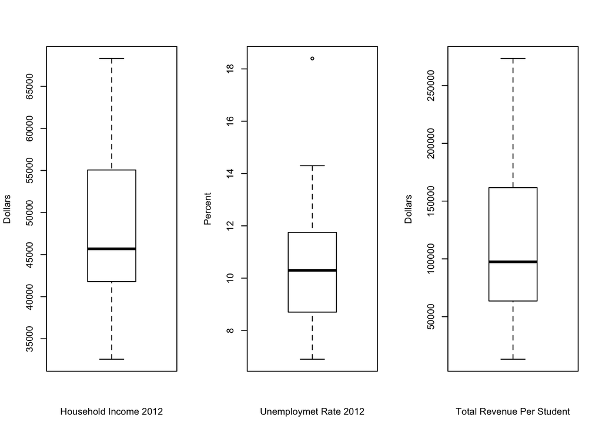

```r
par(mfrow = c(1,3))
boxplot(dropout$Median_household_income_2012,   xlab="Household Income 2012", ylab="Dollars")
boxplot(dropout$unemployment_rate,  xlab="Unemploymet Rate 2012", ylab="Percent")
boxplot(dropout$TotalRevenuePerStudent, xlab="Total Revenue Per Student", ylab="Dollars")
```

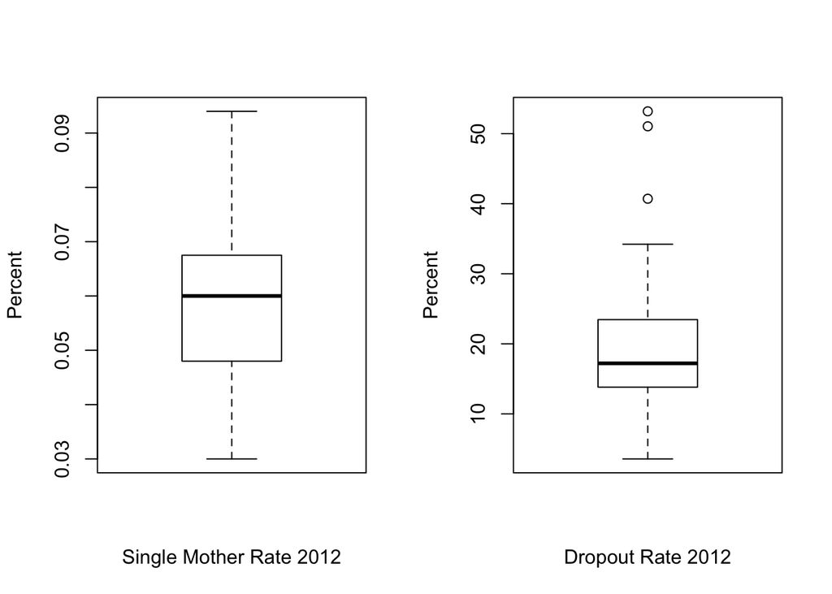

```r
par(mfrow = c(1,2))
boxplot(dropout$single_female_with_children,    xlab="Single Mother Rate 2012", ylab="Percent")
boxplot(dropout$Dropout_Rate,   xlab="Dropout Rate 2012", ylab="Percent")
```

## Regression

Here shows the correlation coefficient between each variables and whether it is signicicative. We can see that all the variables do Not reaching a statistically significant level, which means my data can’t properly catch the social complexity. If we have more theoretical support for choosing independent, we may improve this situation. Also, some of the correlation coefficients within my independent variables are too high,like “TotalRevenuePerStudent,” “TotalFederalRevenuePerStudent,” “TotalLocalRevenuePerStudent” and “TotalStateRevenuePerStudent,” which may affect the accuracy of the analysis.

```r
explanans=names(dropout)[c(3,4,5,7,8,9,10,11,12,13,14,15,16)]
for (x in explanans){
    par=cbind(dropout[,x],dropout$Dropout_Rate)
    p=cor.test(dropout[,x],dropout$Dropout_Rate)
    print(paste("Pearson:",p$estimate," - Is significative?",p$p.value<0.05))
}
```

```
## [1] "Pearson: -0.140666395003632  - Is significative? FALSE"
## [1] "Pearson: 0.306238793010843  - Is significative? FALSE"
## [1] "Pearson: 0.0821410355478306  - Is significative? FALSE"
## [1] "Pearson: 0.146989506882822  - Is significative? FALSE"
## [1] "Pearson: 0.104783152023587  - Is significative? FALSE"
## [1] "Pearson: -0.1683590811059  - Is significative? FALSE"
## [1] "Pearson: 0.0139880519567922  - Is significative? FALSE"
## [1] "Pearson: -0.0338792201701959  - Is significative? FALSE"
## [1] "Pearson: 0.160412427963589  - Is significative? FALSE"
## [1] "Pearson: -0.161320416953515  - Is significative? FALSE"
## [1] "Pearson: 0.000590874893786439  - Is significative? FALSE"
## [1] "Pearson: -0.128057049392831  - Is significative? FALSE"
## [1] "Pearson: -0.110077728184717  - Is significative? FALSE"
```

```r
cor(dropout[explanans])
```

```
##                                    Median_household_income_2012
## Median_household_income_2012                         1.00000000
## unemployment_rate                                   -0.50111030
## single_female_with_children                          0.19022796
## single_male_with_children                           -0.09648420
## American_indian_and_Native_Alaskan                  -0.41373794
## Black_percentage                                     0.61839701
## White_percentage                                    -0.22367061
## TotalRevenuePerStudent                               0.05693632
## TotalFederalRevenuePerStudent                       -0.21894455
## TotalLocalRevenuePerStudent                          0.34099725
## TotalStateRevenuePerStudent                         -0.04186158
## Student_number                                       0.62986868
## Number_of_public_schools                             0.59737930
##                                    unemployment_rate
## Median_household_income_2012             -0.50111030
## unemployment_rate                         1.00000000
## single_female_with_children               0.03261247
## single_male_with_children                 0.54749562
## American_indian_and_Native_Alaskan        0.69156574
## Black_percentage                         -0.38119791
## White_percentage                         -0.03606680
## TotalRevenuePerStudent                   -0.09335831
## TotalFederalRevenuePerStudent             0.50829173
## TotalLocalRevenuePerStudent              -0.33435821
## TotalStateRevenuePerStudent              -0.06066102
## Student_number                           -0.34076925
## Number_of_public_schools                 -0.32442797
##                                    single_female_with_children
## Median_household_income_2012                        0.19022796
## unemployment_rate                                   0.03261247
## single_female_with_children                         1.00000000
## single_male_with_children                           0.67469150
## American_indian_and_Native_Alaskan                 -0.02228868
## Black_percentage                                    0.26445757
## White_percentage                                   -0.66658076
## TotalRevenuePerStudent                              0.14329965
## TotalFederalRevenuePerStudent                       0.21751418
## TotalLocalRevenuePerStudent                         0.02411286
## TotalStateRevenuePerStudent                         0.16475796
```

[output cut: 99 more lines]

```
## Number_of_public_schools                            0.39981916
##                                    Student_number Number_of_public_schools
## Median_household_income_2012           0.62986868               0.59737930
## unemployment_rate                     -0.34076925              -0.32442797
## single_female_with_children            0.21335537               0.21287723
## single_male_with_children             -0.07666778              -0.08042395
## American_indian_and_Native_Alaskan    -0.16358265              -0.14810086
## Black_percentage                       0.84479084               0.85057299
## White_percentage                      -0.40737080              -0.39844283
## TotalRevenuePerStudent                 0.50549060               0.54449783
## TotalFederalRevenuePerStudent          0.16215243               0.20456465
## TotalLocalRevenuePerStudent            0.75604723               0.78284315
## TotalStateRevenuePerStudent            0.36181580               0.39981916
## Student_number                         1.00000000               0.99513556
## Number_of_public_schools               0.99513556               1.00000000
```

#### Here shows the plot of the highest correlation coefficient of my chosen variables and the dropout rate.

Pearson =0.306

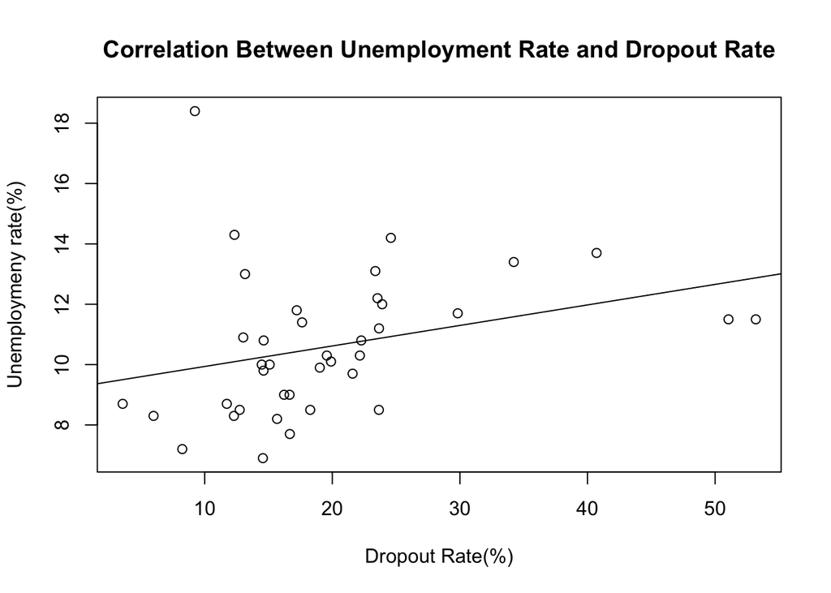

```r
plot(x=dropout$Dropout_Rate,      #  Values for X axis
     y=dropout$unemployment_rate,       # Values for Y axis
     main="Correlation Between Unemployment Rate and Dropout Rate",    # Title
     xlab="Dropout Rate(%)",       # Name of X axis
     ylab="Unemploymeny rate(%)"         # Name of Y axis
)

abline(lm(unemployment_rate~ Dropout_Rate, data=dropout))  # Linear model
```

Pearson=0.08

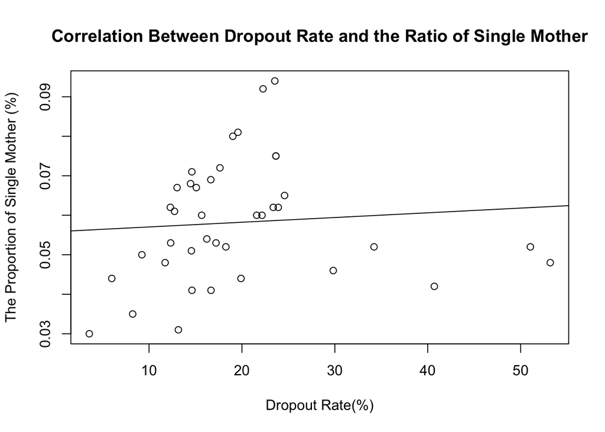

```r
plot(x=dropout$Dropout_Rate,      #  Values for X axis
     y=dropout$single_female_with_children,       # Values for Y axis
     main="Correlation Between Dropout Rate and the Ratio of Single Mother",    # Title
     xlab="Dropout Rate(%)",       # Name of X axis
     ylab="The Proportion of Single Mother (%)"         # Name of Y axis
)
abline(lm(single_female_with_children~ Dropout_Rate, data=dropout))
```

# Mutiple Regression

From the results, we can see that the p-value is 0.4797>0.05 and the R-squared is 0.09491, so our indenpendent variables can only limitedly explain the denpendent varibale.

```r
row.names(dropout)=dropout$County

LinRegEPI = lm(Dropout_Rate ~ TotalFederalRevenuePerStudent + unemployment_rate + single_male_with_children + Median_household_income_2012,
               data = dropout)

summary(LinRegEPI)
```

```
##
## Call:
## lm(formula = Dropout_Rate ~ TotalFederalRevenuePerStudent + unemployment_rate +
##     single_male_with_children + Median_household_income_2012,
##     data = dropout)
##
## Residuals:
##     Min      1Q  Median      3Q     Max
## -21.504  -4.325  -0.803   2.586  31.950
##
## Coefficients:
##                                 Estimate Std. Error t value Pr(>|t|)
## (Intercept)                    3.751e+00  1.771e+01   0.212    0.833
## TotalFederalRevenuePerStudent  1.362e-05  2.881e-04   0.047    0.963
## unemployment_rate              1.506e+00  1.114e+00   1.352    0.185
## single_male_with_children     -5.902e+01  3.226e+02  -0.183    0.856
## Median_household_income_2012   3.135e-05  2.398e-04   0.131    0.897
##
## Residual standard error: 10.52 on 34 degrees of freedom
## Multiple R-squared:  0.09491,    Adjusted R-squared:  -0.01157
## F-statistic: 0.8914 on 4 and 34 DF,  p-value: 0.4797
```

The adjusted R-squared usually is from 0 to 1, the closer to 1 the better, and ours is -0.01, which means a little.

```r
results=coef(summary(LinRegEPI))

data.frame(Coefficient=results[,1],Significant=results[,4]<0.05)
```

```
##                                 Coefficient Significant
## (Intercept)                    3.751162e+00       FALSE
## TotalFederalRevenuePerStudent  1.361988e-05       FALSE
## unemployment_rate              1.505558e+00       FALSE
## single_male_with_children     -5.902272e+01       FALSE
## Median_household_income_2012   3.134775e-05       FALSE
```

```r
summary(LinRegEPI)$adj.r.squared
```

```
## [1] -0.01156577
```

## Logistic Regression

We run logistic regression and find out that the binomianl variable (Region: Urban/ country) don’t affect those variables and don’t reach a siginificant level statistically. So, my data shows that there are no significant difference between rural and urban areas.

```r
LogitEPI_a = glm(factor(Region) ~ TotalFederalRevenuePerStudent + unemployment_rate + Dropout_Rate,
                  data = dropout, family = binomial()
                  )

results=coef(summary(LogitEPI_a))
data.frame(CoefficientExp=exp(results[,1]),Significant=results[,4]<0.05)
```

```
##                               CoefficientExp Significant
## (Intercept)                       91.7156363       FALSE
## TotalFederalRevenuePerStudent      1.0000725       FALSE
## unemployment_rate                  0.5461485       FALSE
## Dropout_Rate                       0.9698296       FALSE
```

## Clustering

From the dendrogram, we can see that King county is the outliner of the data, I use different methods(average and ercliedean) to classify my data, both show the similar reseult.

NOTE: The following two plots are ploted according to all the independent variables.

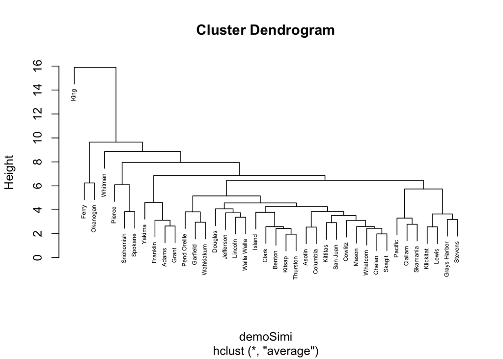

```r
library(cluster)
row.names(dropout)=dropout$County
demoSimi=daisy(dropout[,c(2:16)],metric = "euclidean",
               stand=TRUE)
demoClus=hclust(demoSimi,method = 'average')
plot(demoClus,cex=0.5)
```

```r
data <- dropout[, -1]
E.dist <- dist(data, method="euclidean")
```

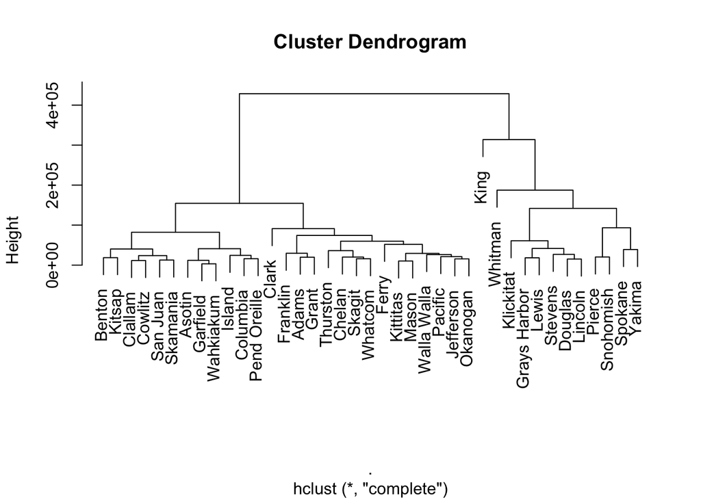

```r
E.dist %>% hclust()%>% plot()%>% par(mfrow=c(1,2))
```

```r
library("tidyverse")
Cluster<-data%>% dist(method="euclidean")%>% hclust(method= "ward.D2")
```

## Mapping

```r
library(jsonlite)
is.data.frame(dropout)
```

```
## [1] TRUE
```

```r
dropout1=dropout[,c('County','TotalRevenuePerStudent','Student_number')]
str(dropout1)
```

```
## 'data.frame':    39 obs. of  3 variables:
##  $ County                : Factor w/ 39 levels "Adams","Asotin",..: 1 2 3 4 5 6 7 8 9 10 ...
##  $ TotalRevenuePerStudent: int  116003 21747 69509 83872 61014 97295 32795 65721 156019 85383 ...
##  $ Student_number        : int  4703 3296 35396 13329 10462 79279 472 16702 7249 853 ...
```

```r
Map="https://github.com/liuuw/PROJECT/raw/master/WAOFM%20-%20GIS%20-%20County%20Boundary.zip"
```

We load the Shape file first.

```r
library(utils)
temp=tempfile()
download.file(Map, temp)
unzip(temp)
(maps=list.files(pattern = 'shp'))
```

```
## [1] "geo_export_109cf655-8ce8-4eea-8b93-dc816b22de53.shp"
## [2] "ShapeFile.shp"
```

```r
library(rgdal)
wazipMap <- rgdal::readOGR("geo_export_109cf655-8ce8-4eea-8b93-dc816b22de53.shp",stringsAsFactors=F) # use name
names(wazipMap)
```

```
## [1] "countyfp" "name"
```

```r
str(wazipMap$name)
```

```
##  chr [1:39] "Adams" "Asotin" "Benton" "Chelan" "Clallam" "Clark" ...
```

```r
str(dropout$County)
```

```
##  Factor w/ 39 levels "Adams","Asotin",..: 1 2 3 4 5 6 7 8 9 10 ...
```

```r
contribWAmap=merge(wazipMap,dropout, by.x='name', by.y='County',all.x=F)
nrow(contribWAmap)
```

```
## [1] 39
```

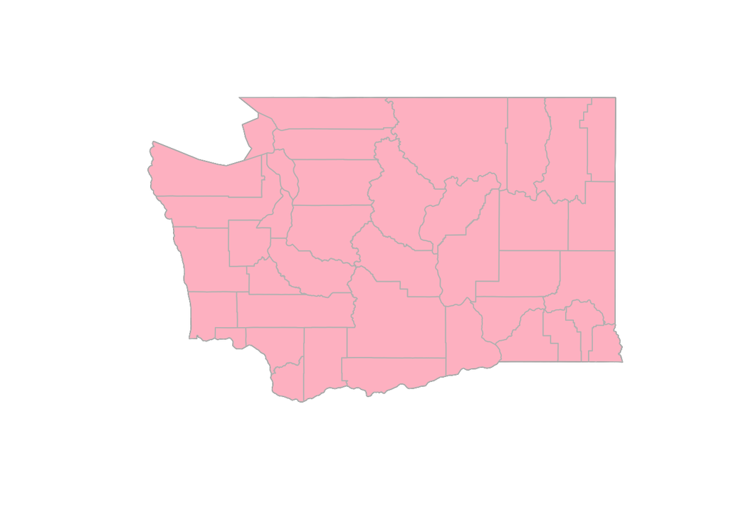

```r
plot(wazipMap,col='black')
plot(contribWAmap,col='pink',border='grey',add=T)
```

And plot it with different colors in terms of the Dropout rate, Number of students, Number of Schools and Total Revenue.

### Map.1

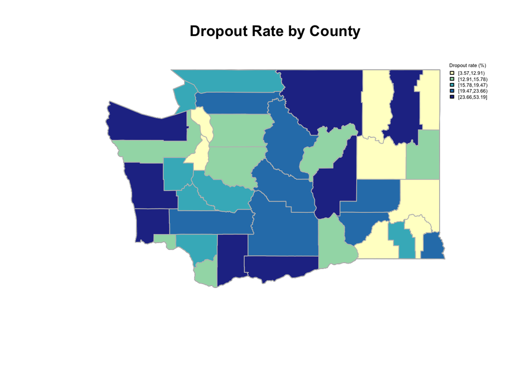

```r
library(RColorBrewer)
library(classInt)
varToPLot=contribWAmap$Dropout_Rate

numberOfClasses = 5
colorForScale='YlGnBu'
colors = brewer.pal(numberOfClasses, colorForScale)
intervals <- classIntervals(varToPLot, numberOfClasses,
                            style = "quantile",
                            dataPrecision=2)
colorPallette <- findColours(intervals, colors)

legendText="Dropout rate (%)"
shrinkLegend=0.4
title="Dropout Rate by County"

plot(wazipMap,col='red',main=title)
plot(contribWAmap, col = colorPallette,border='grey',add=T)

legend('topright', legend = names(attr(colorPallette, "table")),
       fill = attr(colorPallette, "palette"), cex = shrinkLegend,
       bty = "n",
       title=legendText)
```

### Map.2

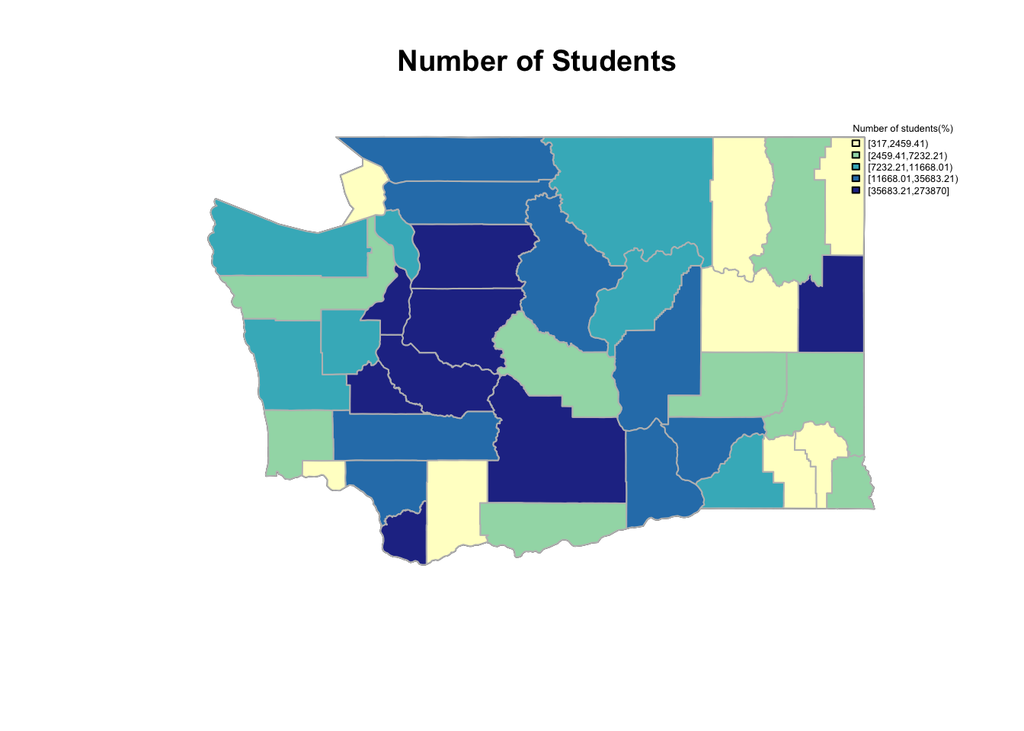

```r
library(RColorBrewer)
library(classInt)
varToPLot=contribWAmap$Student_number

numberOfClasses = 5
colorForScale='YlGnBu'
colors = brewer.pal(numberOfClasses, colorForScale)
intervals <- classIntervals(varToPLot, numberOfClasses,
                            style = "quantile",
                            dataPrecision=2)
colorPallette <- findColours(intervals, colors)

legendText="Number of students(%)"
shrinkLegend=0.4
title="Number of Students "

plot(wazipMap,col='red',main=title)
plot(contribWAmap, col = colorPallette,border='grey',add=T)

legend('topright', legend = names(attr(colorPallette, "table")),
       fill = attr(colorPallette, "palette"), cex = shrinkLegend,
       bty = "n",
       title=legendText)
```

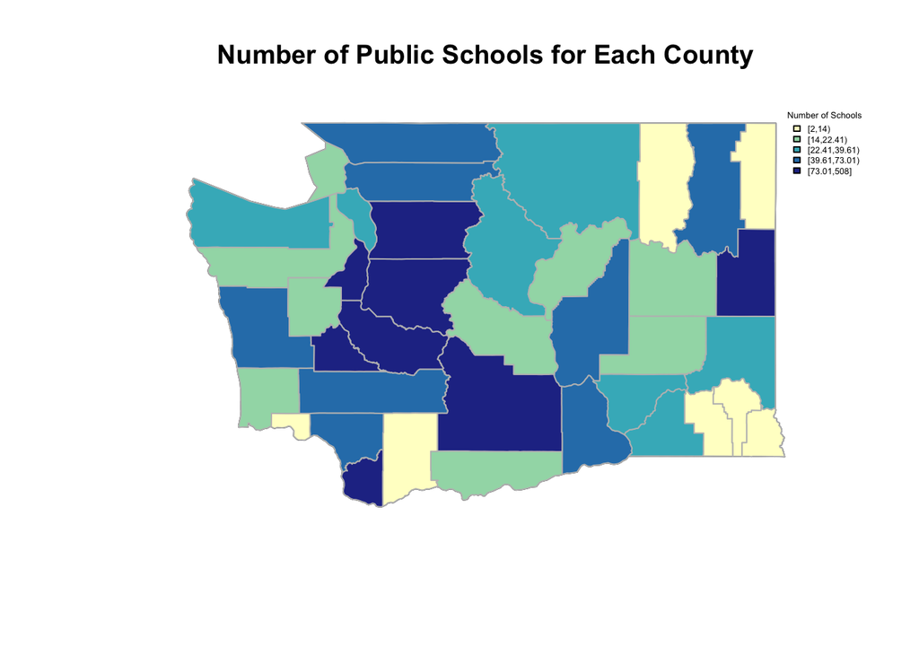

```r
library(RColorBrewer)
library(classInt)
varToPLot=contribWAmap$Number_of_public_schools

numberOfClasses = 5
colorForScale='YlGnBu'
colors = brewer.pal(numberOfClasses, colorForScale)
intervals <- classIntervals(varToPLot, numberOfClasses,
                            style = "quantile",
                            dataPrecision=2)
colorPallette <- findColours(intervals, colors)

legendText="Number of Schools"
shrinkLegend=0.4
title="Number of Public Schools for Each County"

plot(wazipMap,col='red',main=title)
plot(contribWAmap, col = colorPallette,border='grey',add=T)

legend('topright', legend = names(attr(colorPallette, "table")),
       fill = attr(colorPallette, "palette"), cex = shrinkLegend,
       bty = "n",
       title=legendText)
```

### Map.4

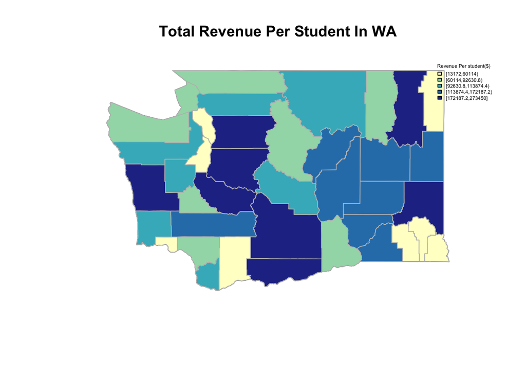

```r
library(RColorBrewer)
library(classInt)
varToPLot=contribWAmap$TotalRevenuePerStudent

numberOfClasses = 5
colorForScale='YlGnBu'
colors = brewer.pal(numberOfClasses, colorForScale)
intervals <- classIntervals(varToPLot, numberOfClasses,
                            style = "quantile",
                            dataPrecision=2)
colorPallette <- findColours(intervals, colors)

legendText="Revenue Per student($)"
shrinkLegend=0.4
title="Total Revenue Per Student In WA"

plot(wazipMap,col='red',main=title)
plot(contribWAmap, col = colorPallette,border='grey',add=T)

legend('topright', legend = names(attr(colorPallette, "table")),
       fill = attr(colorPallette, "palette"), cex = shrinkLegend,
       bty = "n",
       title=legendText)
```